# Educational data Mining using ANN

Bharath Karumudi

5/6/2019

### Introduction

A kaggle dataset on student academic performance (available through https://www.kaggle.com/aljarah/xAPI-Edu-Data) is gathered to identify the influential factors for students’ performance.

To predict the students’ performance, the collected data was organized into four kinds of features: demographic, academic background, parents’ participation on learning process and behavioral features.

### Install required Packages

```
(if needed)
```

```r
# install.packages("ggplot2")
# install.packages("lattice")
# install.packages("caret")
# install.packages("C50")
# install.packages("randomForest")
# install.packages("nnet")
# install.packages("RRF")
```

### Load the required libraries

```r
library(ggplot2)
library(lattice)
library(caret)
library(C50)
library(randomForest)
library(nnet)
library(rattle)
library(RRF)
```

### Loading the dataset

```r
educational_dataset <- read.csv("Students_Academic_Performance.csv" )

cat("Let's see the data:")
```

```
## Let's see the data:
```

```r
dim(educational_dataset)
```

```
## [1] 480  17
```

```r
head(educational_dataset)
```

```
##   gender NationalITy PlaceofBirth    StageID GradeID SectionID Topic
## 1      M          KW       KuwaIT lowerlevel    G-04         A    IT
## 2      M          KW       KuwaIT lowerlevel    G-04         A    IT
## 3      M          KW       KuwaIT lowerlevel    G-04         A    IT
## 4      M          KW       KuwaIT lowerlevel    G-04         A    IT
## 5      M          KW       KuwaIT lowerlevel    G-04         A    IT
## 6      F          KW       KuwaIT lowerlevel    G-04         A    IT
##   Semester Relation raisedhands VisITedResources AnnouncementsView
## 1        F   Father          15               16                 2
## 2        F   Father          20               20                 3
## 3        F   Father          10                7                 0
## 4        F   Father          30               25                 5
## 5        F   Father          40               50                12
## 6        F   Father          42               30                13
##   Discussion ParentAnsweringSurvey ParentschoolSatisfaction
## 1         20                   Yes                     Good
## 2         25                   Yes                     Good
## 3         30                    No                      Bad
## 4         35                    No                      Bad
## 5         50                    No                      Bad
## 6         70                   Yes                      Bad
##   StudentAbsenceDays Class
## 1            Under-7     M
## 2            Under-7     M
## 3            Above-7     L
## 4            Above-7     L
## 5            Above-7     M
## 6            Above-7     M
```

```r
summary(educational_dataset)
```

```
##  gender     NationalITy       PlaceofBirth         StageID
##  F:175   KW       :179   KuwaIT     :180   HighSchool  : 33
##  M:305   Jordan   :172   Jordan     :176   lowerlevel  :199
##          Palestine: 28   Iraq       : 22   MiddleSchool:248
##          Iraq     : 22   lebanon    : 19
##          lebanon  : 17   SaudiArabia: 16
##          Tunis    : 12   USA        : 16
##          (Other)  : 50   (Other)    : 51
##     GradeID    SectionID     Topic     Semester   Relation
##  G-02   :147   A:283     IT     : 95   F:245    Father:283
##  G-08   :116   B:167     French : 65   S:235    Mum   :197
##  G-07   :101   C: 30     Arabic : 59
##  G-04   : 48             Science: 51
##  G-06   : 32             English: 45
##  G-11   : 13             Biology: 30
##  (Other): 23             (Other):135
##   raisedhands     VisITedResources AnnouncementsView   Discussion
##  Min.   :  0.00   Min.   : 0.0     Min.   : 0.00     Min.   : 1.00
##  1st Qu.: 15.75   1st Qu.:20.0     1st Qu.:14.00     1st Qu.:20.00
##  Median : 50.00   Median :65.0     Median :33.00     Median :39.00
##  Mean   : 46.77   Mean   :54.8     Mean   :37.92     Mean   :43.28
##  3rd Qu.: 75.00   3rd Qu.:84.0     3rd Qu.:58.00     3rd Qu.:70.00
##  Max.   :100.00   Max.   :99.0     Max.   :98.00     Max.   :99.00
##
##  ParentAnsweringSurvey ParentschoolSatisfaction StudentAbsenceDays Class
##  No :210               Bad :188                 Above-7:191        H:142
##  Yes:270               Good:292                 Under-7:289        L:127
##                                                                    M:211
##
##
##
##
```

### RFE Model

We can identify the attributes that are not required by using Recursive Feature Elimination method (RFE).

```r
set.seed(1234)

rfe_control_params <- rfeControl(functions=rfFuncs, method="cv", number=10)

rfe_method<- rfe(educational_dataset[,1:16], educational_dataset[,17], sizes=c(1:17), rfeControl=rfe_control_params)
print(rfe_method)
```

```
##
## Recursive feature selection
##
## Outer resampling method: Cross-Validated (10 fold)
##
## Resampling performance over subset size:
##
##  Variables Accuracy  Kappa AccuracySD KappaSD Selected
##          1   0.5208 0.2614    0.02631 0.03523
##          2   0.6457 0.4630    0.04099 0.05403
##          3   0.6896 0.5257    0.05226 0.07535
##          4   0.7141 0.5620    0.06140 0.09099
##          5   0.7100 0.5539    0.04795 0.07220
##          6   0.7395 0.5987    0.06335 0.09745
##          7   0.7559 0.6233    0.06157 0.09386
##          8   0.7582 0.6253    0.04144 0.06600
##          9   0.7604 0.6284    0.05051 0.07584
##         10   0.7956 0.6835    0.04889 0.07472
##         11   0.7872 0.6706    0.04838 0.07437
##         12   0.7956 0.6830    0.05748 0.08848
##         13   0.7915 0.6757    0.04281 0.06598
##         14   0.7851 0.6662    0.03986 0.06206
##         15   0.8082 0.7024    0.04792 0.07475        *
##         16   0.7976 0.6858    0.04990 0.07692
##
## The top 5 variables (out of 15):
##    StudentAbsenceDays, VisITedResources, raisedhands, AnnouncementsView, ParentAnsweringSurvey
```

```r
predictors(rfe_method)
```

```
##  [1] "StudentAbsenceDays"       "VisITedResources"
##  [3] "raisedhands"              "AnnouncementsView"
##  [5] "ParentAnsweringSurvey"    "Relation"
##  [7] "Discussion"               "Topic"
##  [9] "NationalITy"              "ParentschoolSatisfaction"
## [11] "gender"                   "PlaceofBirth"
## [13] "GradeID"                  "StageID"
## [15] "SectionID"
```

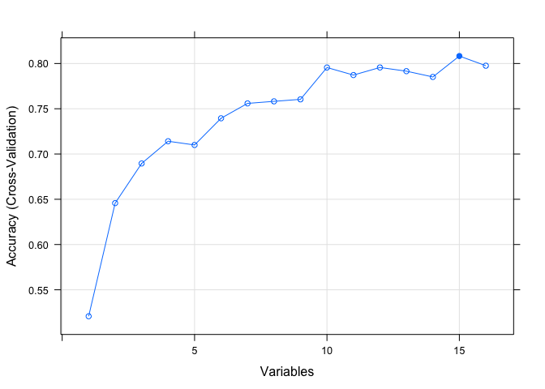

```r
plot(rfe_method, type=c("g", "o"))
```

### Train an rpart model to compute variable importance

```r
# Train an rpart model and compute variable importance.
set.seed(100)
rPartMod <- train(Class ~ ., data=educational_dataset, method="rpart")
rpartImp <- varImp(rPartMod)
print(rpartImp)
```

```
## rpart variable importance
##
##   only 20 most important variables shown (out of 61)
##
##                              Overall
## VisITedResources              100.00
## raisedhands                    83.50
## AnnouncementsView              74.62
## StudentAbsenceDaysUnder-7      56.96
## ParentAnsweringSurveyYes       43.45
## RelationMum                    16.92
## ParentschoolSatisfactionGood   16.12
## NationalITyIran                 0.00
## PlaceofBirthUSA                 0.00
## StageIDlowerlevel               0.00
## NationalITyJordan               0.00
## NationalITyIraq                 0.00
## `GradeIDG-12`                   0.00
## PlaceofBirthKuwaIT              0.00
## TopicGeology                    0.00
## NationalITylebanon              0.00
## PlaceofBirthMorocco             0.00
## `GradeIDG-10`                   0.00
## TopicIT                         0.00
## NationalITyMorocco              0.00
```